# Systemic lupus erythematosus whole blood compendium PLIER training

**J. Taroni 2018**

In this notebook, we’ll train a PLIER model on the systemic lupus erythematosis (SLE) whole blood (WB) compendium we processed in [`greenelab/rheum-plier-data/sle-wb`](https://github.com/greenelab/rheum-plier-data/tree/4be547553f24fecac9e2f5c2b469a17f9df253f0/sle-wb) and do some exploratory data analysis.

## Functions and directory set up

```r
library(AnnotationDbi)
`%>%` <- dplyr::`%>%`
# custom functions
source(file.path("util", "plier_util.R"))
```

```r
# plot and result directory setup for this notebook
plot.dir <- file.path("plots", "05")
dir.create(plot.dir, recursive = TRUE, showWarnings = FALSE)
results.dir <- file.path("results", "05")
dir.create(results.dir, recursive = TRUE, showWarnings = FALSE)
```

## Load SLE WB data

```r
exprs.file <- file.path("data", "expression_data",
                        "SLE_WB_all_microarray_QN_zto_before.pcl")
exprs.df <- readr::read_tsv(exprs.file)
```

### Annotation

```r
symbol.obj <- org.Hs.eg.db::org.Hs.egSYMBOL
```

```r
mapped.genes <- AnnotationDbi::mappedkeys(symbol.obj)
symbol.list <- as.list(symbol.obj[mapped.genes])
symbol.df <- as.data.frame(cbind(names(symbol.list), unlist(symbol.list)))
colnames(symbol.df) <- c("EntrezID", "GeneSymbol")
# get gene column name to match to facilitate use with dplyr
colnames(exprs.df)[1] <- "EntrezID"
# matching types
symbol.df$EntrezID <- as.integer(as.character(symbol.df$EntrezID))
# inner join
annot.exprs.df <- dplyr::inner_join(symbol.df, exprs.df, by = "EntrezID")
symbol.file <-
  file.path("data", "expression_data",
            "SLE_WB_all_microarray_QN_zto_before_with_GeneSymbol.pcl")
readr::write_delim(annot.exprs.df, path = symbol.file, delim = "\t")
# matrix with gene symbol as rownames
exprs.mat <- dplyr::select(annot.exprs.df, -EntrezID)
rownames(exprs.mat) <- exprs.mat$GeneSymbol
exprs.mat <- as.matrix(dplyr::select(exprs.mat, -GeneSymbol))
```

```r
exprs.mat[1:5, 1:5]
```

```
           GSM955680_DNA10204-001.CEL GSM955681_DNA10204-003.CEL GSM955682_DNA10204-005.CEL GSM955683_DNA10204-007.CEL
NAT2                        0.2872200                  0.6788542                  0.0000000                  0.4627302
ADA                         0.7331941                  0.6073631                  0.5483356                  0.4294504
CDH2                        0.2431701                  0.3168936                  0.3041239                  0.6799173
AKT3                        0.6418411                  0.3147596                  0.3863309                  0.5632609
ZBTB11-AS1                  0.2541135                  0.5831909                  0.3406465                  0.4724936
           GSM955684_DNA10204-011.CEL
NAT2                        0.4656660
ADA                         0.5349434
CDH2                        0.1800279
AKT3                        0.4955665
ZBTB11-AS1                  0.3203299
```

## PLIER model training

```r
plier.result <- PLIERNewData(exprs.mat = exprs.mat)
```

```
Using rsvd: set seed for consistent results
Removing 1 pathways with too few genesComputing SVD
Using rsvd: set seed for consistent results
Done
```

```
[1] 72.91089
[1] "L2 is set to 72.9108889298683"
[1] "L1 is set to 36.4554444649342"
```

[output not shown]

[output cut: 174 more lines]

```
Bdiff is not decreasing
iter196 errorY= 0.3696, prior information ratio= 0.02, Bdiff= 9.601e-05, Bkappa=7.342e+20;pos. col. U=101
Bdiff is not decreasing
iter197 errorY= 0.3696, prior information ratio= 0.02, Bdiff= 9.62e-05, Bkappa=1.131e+21;pos. col. U=101
Bdiff is not decreasing
iter198 errorY= 0.3696, prior information ratio= 0.02, Bdiff= 9.671e-05, Bkappa=1.466e+21;pos. col. U=101
Bdiff is not decreasing
iter199 errorY= 0.3696, prior information ratio= 0.02, Bdiff= 9.696e-05, Bkappa=2.004e+21;pos. col. U=101
Bdiff is not decreasing
Updating L3, current fraction= 0.7113, target=0.7
L3 is set to 0.004195 in 10 iterations
iter200 errorY= 0.3696, prior information ratio= 0.02, Bdiff= 0.0001001, Bkappa=2.482e+21;pos. col. U=99
Bdiff is not decreasing
converged at  iteration 200 Bdiff is not decreasing
There are 57  LVs with AUC>0.70
```

```r
model.file <- file.path(results.dir, "SLE-WB_PLIER_model.RDS")
saveRDS(plier.result, file = model.file)
```

## Explore SLE WB PLIER model

### U matrix

We can get an overview of what pathways are captured with the LVs by plotting `U` with `PLIER::plotU`. `U` is the prior information coefficient matrix; it tells us how the prior information in the form of pathways/gene sets relates to LVs.

```r
pdf(file.path(plot.dir, "SLE-WB_PLIER_Uplot_auc0.75.pdf"))
PLIER::plotU(plier.result, auc.cutoff = 0.75, fontsize_row = 4,
             fontsize_col = 7)
dev.off()
```

#### All LVs

What proportion of entries in `U` are non-zero (column-wise)? As a reminder, the fewer pathways that are associated with an LV (column), the easier interpretation will be. (Sparsity of `U` is a constraint in PLIER.)

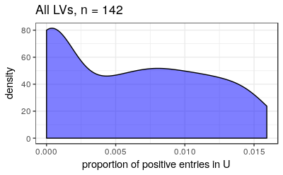

```r
num.lvs <- ncol(plier.result$Z)
u.sparsity.all <- CalculateUSparsity(plier.results = plier.result,
                                     significant.only = FALSE)
ggplot2::ggplot(as.data.frame(u.sparsity.all),
                ggplot2::aes(x = u.sparsity.all)) +
  ggplot2::geom_density(fill = "blue", alpha = 0.5) +
  ggplot2::theme_bw() +
  ggplot2::labs(x = "proportion of positive entries in U",
                title = paste("All LVs, n =", num.lvs))
```

```r
plot.file <- file.path(plot.dir,
                       "SLE-WB_model_U_sparsity_all_density.png")
ggplot2::ggsave(plot.file, plot = ggplot2::last_plot(),
                height = 5, width = 7)
```

```r
summary(u.sparsity.all)
```

```
    Min.  1st Qu.   Median     Mean  3rd Qu.     Max.
0.000000 0.000000 0.005573 0.006033 0.011146 0.015924
```

#### Pathway-associated LVs

Now, only with *significant* associations (`FDR < 0.05`).

```r
plier.summary <- plier.result$summary
sig.summary <- plier.summary %>%
  dplyr::filter(FDR < 0.05)
num.sig.lvs <- length(unique(sig.summary$`LV index`))
```

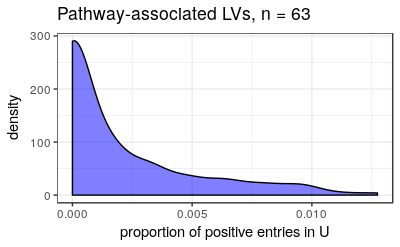

```r
u.sparsity.sig <- CalculateUSparsity(plier.results = plier.result,
                                     significant.only = TRUE,
                                     fdr.cutoff = 0.05)
ggplot2::ggplot(as.data.frame(u.sparsity.sig),
                ggplot2::aes(x = u.sparsity.sig)) +
  ggplot2::geom_density(fill = "blue", alpha = 0.5) +
  ggplot2::theme_bw() +
  ggplot2::labs(x = "proportion of positive entries in U",
                title = paste("Pathway-associated LVs, n =", num.sig.lvs))
```

```r
plot.file <- file.path(plot.dir,
                       "SLE-WB_model_U_sparsity_sig_density.png")
ggplot2::ggsave(plot.file, plot = ggplot2::last_plot(),
                height = 5, width = 7)
```

```r
summary(u.sparsity.sig)
```

```
    Min.  1st Qu.   Median     Mean  3rd Qu.     Max.
0.000000 0.000000 0.000000 0.001929 0.003185 0.012739
```

### Pathway coverage

What proportion of the pathways input into the model are significantly associated (`FDR < 0.05`) with an LV?

```r
sle.coverage <- GetPathwayCoverage(plier.results = plier.result)
# Pathway coverage
sle.coverage$pathway
```

```
[1] 0.1942675
```

Less pathways are “covered” with this model than the recount2 model, where coverage was `0.419`.

### PCA of lower-dimensional (LV) space

We’ll perform PCA on the `B` matrix from the SLE WB PLIER model. This is mainly for visualization purposes.

The `B` matrix contains the samples values for each LV (from the model under consideration – here, the SLE WB PLIER model), where rows are LVs and samples are columns.

As noted when we prepped the data in [`greenelab/rheum-plier-data/sle-wb`](https://github.com/greenelab/rheum-plier-data/tree/4be547553f24fecac9e2f5c2b469a17f9df253f0/sle-wb), [there are still differences](https://github.com/greenelab/rheum-plier-data/blob/4be547553f24fecac9e2f5c2b469a17f9df253f0/sle-wb/plots/PCA/SLE_WB_all_microarray_QN_PC1-5_zto.before.png) between datasets in the final compendium.

If the LVs that are not associated with any pathway (all `AUC < 0.75`) in fact capture nuisance variables, we expect that dropping them from the `B` matrix may reduce the dataset effect.

The AUC (and p-values) are calculated by holding out 1/5th of genes in a pathway (in the prior information matrix `C`), running PLIER, and testing how well the loadings in `Z` capture the held-out genes. For more information, check out the [PLIER preprint (Mao, et al. 2017.)](https://doi.org/10.1101/116061).

```r
# Which LVs have pathways with AUC > 0.75?
lv.auc <-
  as.integer(unique(plier.summary$`LV index`[which(plier.summary$AUC > 0.75)]))
# B matrix
b.matrix <- as.matrix(plier.result$B)
# B matrix -- only LV AUC > 0.75 (any pathway)
sig.b.mat <- b.matrix[lv.auc, ]
# B matrix all other LV
oth.b.mat <- b.matrix[-lv.auc, ]
```

```r
# color palette for PCA plots
plot.color.pal <- c("#54FF9F", "#43CD80", "#2E8B57", "#006400", "#FF8C00",
                    "#8B4500", "#000080")
# read sample dataset mapping file
sd.file <- file.path("data", "sample_info", "sle-wb_sample_dataset_mapping.tsv")
sd.df <- readr::read_tsv(sd.file)
```

#### All latent variables

```r
# PCA
all.lv.pc <- prcomp(t(b.matrix))
cum.var.exp <- cumsum(all.lv.pc$sdev^2 / sum(all.lv.pc$sdev^2))
# PC1-2 in form suitable for ggplot2
all.lv.df <- as.data.frame(cbind(rownames(all.lv.pc$x),
                                 all.lv.pc$x[, 1:2]))
colnames(all.lv.df)[1] <- "SampleID"
# add dataset of origin info
all.lv.df <- dplyr::full_join(all.lv.df, sd.df, by = "SampleID") %>%
  dplyr::mutate(PC1 = as.numeric(as.character(PC1)),
                PC2 = as.numeric(as.character(PC2)),
                Dataset = factor(Dataset,
                                 levels = c("E-GEOD-39088",
                                            "E-GEOD-61635",
                                            "E-GEOD-72747",
                                            "E-GEOD-11907",
                                            "E-GEOD-49454",
                                            "E-GEOD-65391",
                                            "E-GEOD-78193")))
```

```
Column `SampleID` joining factor and character vector, coercing into character vector
```

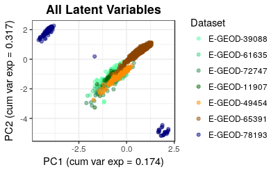

```r
# plotting
all.plot <-
  ggplot2::ggplot(all.lv.df, ggplot2::aes(x = PC1, y = PC2, colour = Dataset)) +
    ggplot2::geom_point(alpha = 0.5) +
    ggplot2::scale_color_manual(values = plot.color.pal) +
    ggplot2::theme_bw() +
    ggplot2::labs(x = paste0("PC1 (cum var exp = ",
                             round(cum.var.exp[1], 3), ")"),
                  y = paste0("PC2 (cum var exp = ",
                             round(cum.var.exp[2], 3), ")"),
                  title = "All Latent Variables") +
    ggplot2::theme(plot.title = ggplot2::element_text(hjust = 0.5,
                                                      face = "bold"))
all.plot
```

#### Pathway-associated latent variables

```r
# PCA
path.lv.pc <- prcomp(t(sig.b.mat))
cum.var.exp <- cumsum(path.lv.pc$sdev^2 / sum(path.lv.pc$sdev^2))
# PC1-2 in form suitable for ggplot2
path.lv.df <- as.data.frame(cbind(rownames(path.lv.pc$x),
                                 path.lv.pc$x[, 1:2]))
colnames(path.lv.df)[1] <- "SampleID"
# add dataset of origin info
path.lv.df <- dplyr::full_join(path.lv.df, sd.df, by = "SampleID") %>%
  dplyr::mutate(PC1 = as.numeric(as.character(PC1)),
                PC2 = as.numeric(as.character(PC2)),
                Dataset = factor(Dataset,
                                 levels = c("E-GEOD-39088",
                                            "E-GEOD-61635",
                                            "E-GEOD-72747",
                                            "E-GEOD-11907",
                                            "E-GEOD-49454",
                                            "E-GEOD-65391",
                                            "E-GEOD-78193")))
```

```
Column `SampleID` joining factor and character vector, coercing into character vector
```

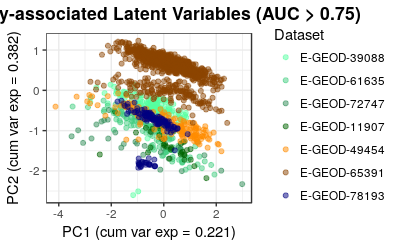

```r
# plotting
path.plot <-
  ggplot2::ggplot(path.lv.df, ggplot2::aes(x = PC1, y = PC2,
                                           colour = Dataset)) +
  ggplot2::geom_point(alpha = 0.5) +
  ggplot2::scale_color_manual(values = plot.color.pal) +
  ggplot2::theme_bw() +
  ggplot2::labs(x = paste0("PC1 (cum var exp = ",
                           round(cum.var.exp[1], 3), ")"),
                y = paste0("PC2 (cum var exp = ",
                           round(cum.var.exp[2], 3), ")"),
                title = "Pathway-associated Latent Variables (AUC > 0.75)") +
  ggplot2::theme(plot.title = ggplot2::element_text(hjust = 0.5,
                                                    face = "bold"))
path.plot
```

#### Other latent variables (AUC <= 0.75)

```r
# PCA
oth.lv.pc <- prcomp(t(oth.b.mat))
cum.var.exp <- cumsum(oth.lv.pc$sdev^2 / sum(oth.lv.pc$sdev^2))
# PC1-2 in form suitable for ggplot2
oth.lv.df <- as.data.frame(cbind(rownames(oth.lv.pc$x),
                                 oth.lv.pc$x[, 1:2]))
colnames(oth.lv.df)[1] <- "SampleID"
# add dataset of origin info
oth.lv.df <- dplyr::full_join(oth.lv.df, sd.df, by = "SampleID") %>%
  dplyr::mutate(PC1 = as.numeric(as.character(PC1)),
                PC2 = as.numeric(as.character(PC2)),
                Dataset = factor(Dataset,
                                 levels = c("E-GEOD-39088",
                                            "E-GEOD-61635",
                                            "E-GEOD-72747",
                                            "E-GEOD-11907",
                                            "E-GEOD-49454",
                                            "E-GEOD-65391",
                                            "E-GEOD-78193")))
```

```
Column `SampleID` joining factor and character vector, coercing into character vector
```

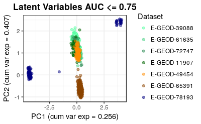

```r
# plotting
oth.plot <-
  ggplot2::ggplot(oth.lv.df, ggplot2::aes(x = PC1, y = PC2, colour = Dataset)) +
    ggplot2::geom_point(alpha = 0.5) +
    ggplot2::scale_color_manual(values = plot.color.pal) +
    ggplot2::theme_bw() +
    ggplot2::labs(x = paste0("PC1 (cum var exp = ",
                           round(cum.var.exp[1], 3), ")"),
                  y = paste0("PC2 (cum var exp = ",
                           round(cum.var.exp[2], 3), ")"),
                  title = "Latent Variables AUC <= 0.75") +
    ggplot2::theme(plot.title = ggplot2::element_text(hjust = 0.5,
                                                      face = "bold"))
oth.plot
```

```r
# Save to PDF
pdf(file.path(plot.dir, "SLE-WB_PLIER_LV_PCA_plots.pdf"), height = 14,
              width = 7)
gridExtra::grid.arrange(all.plot, path.plot, oth.plot, ncol = 1)
dev.off()
```